# Univariate Relationships with Absolute Deviation

# Correlations and Multicollinearity (selected pairs)

This figure shows that for several of the pairs there is substantial correlation between .25 and .5, but for only one pair is the correlation consistently above .5, with the median at .75. This is for the two standard errors. Therefore, in the following we combine both standard error estimates into one average.

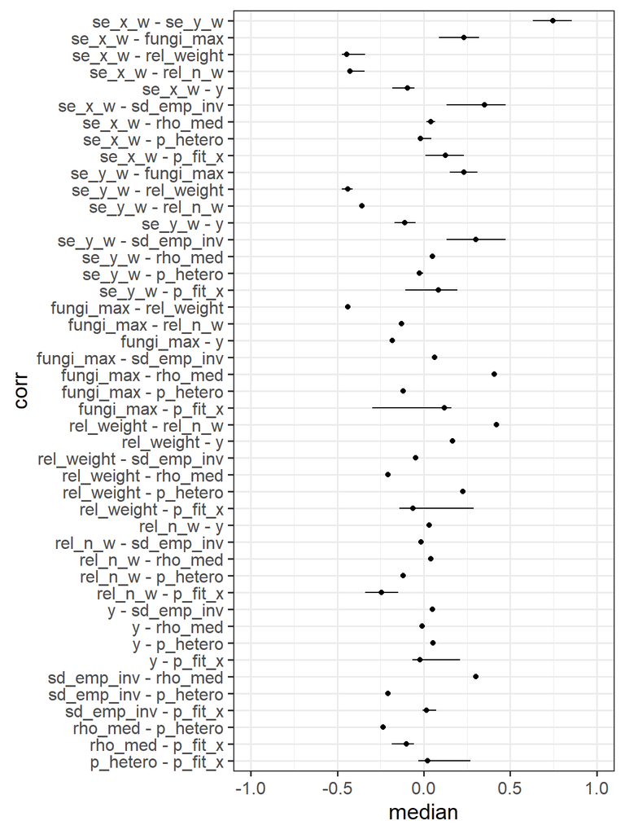

The following table lists the correlation ordered by largest absolute minimum:

```
## # A tibble: 45 x 6
##    corr                     min   max median  mean      sd
##    <fct>                  <dbl> <dbl>  <dbl> <dbl>   <dbl>
##  1 se_x_w - se_y_w         0.63  0.86   0.75  0.75 0.088
##  2 se_x_w - rel_weight    -0.47 -0.34  -0.45 -0.42 0.065
##  3 se_y_w - rel_weight    -0.47 -0.41  -0.44 -0.44 0.028
##  4 fungi_max - rel_weight -0.44 -0.43  -0.44 -0.44 0.0058
##  5 se_x_w - rel_n_w       -0.43 -0.34  -0.43 -0.40 0.037
##  6 rel_weight - rel_n_w    0.42  0.42   0.42  0.42 0.0021
##  7 fungi_max - rho_med     0.41  0.41   0.41  0.41 0.0028
##  8 se_y_w - rel_n_w       -0.37 -0.34  -0.36 -0.36 0.017
##  9 rel_n_w - p_fit_x      -0.34 -0.15  -0.25 -0.25 0.091
## 10 sd_emp_inv - rho_med    0.30  0.30   0.30  0.30 0.00065
## # ... with 35 more rows
```

The following table lists the correlation ordered by largest absolute maximum:

```
## # A tibble: 45 x 6
##    corr                     min   max median  mean     sd
##    <fct>                  <dbl> <dbl>  <dbl> <dbl>  <dbl>
##  1 se_x_w - se_y_w         0.63  0.86   0.75  0.75 0.088
##  2 se_y_w - sd_emp_inv     0.13  0.48   0.30  0.30 0.19
##  3 se_x_w - sd_emp_inv     0.13  0.47   0.35  0.34 0.15
##  4 fungi_max - rel_weight -0.44 -0.43  -0.44 -0.44 0.0058
##  5 rel_weight - rel_n_w    0.42  0.42   0.42  0.42 0.0021
##  6 fungi_max - rho_med     0.41  0.41   0.41  0.41 0.0028
##  7 se_y_w - rel_weight    -0.47 -0.41  -0.44 -0.44 0.028
##  8 se_y_w - rel_n_w       -0.37 -0.34  -0.36 -0.36 0.017
##  9 se_x_w - rel_n_w       -0.43 -0.34  -0.43 -0.40 0.037
## 10 se_x_w - rel_weight    -0.47 -0.34  -0.45 -0.42 0.065
## # ... with 35 more rows
```

The following table lists the correlation ordered by largest absolute median:

```
## # A tibble: 45 x 6
##    corr                      min   max median  mean      sd
##    <fct>                   <dbl> <dbl>  <dbl> <dbl>   <dbl>
##  1 se_x_w - se_y_w         0.63   0.86   0.75  0.75 0.088
##  2 se_x_w - rel_weight    -0.47  -0.34  -0.45 -0.42 0.065
##  3 se_y_w - rel_weight    -0.47  -0.41  -0.44 -0.44 0.028
##  4 fungi_max - rel_weight -0.44  -0.43  -0.44 -0.44 0.0058
##  5 se_x_w - rel_n_w       -0.43  -0.34  -0.43 -0.40 0.037
##  6 rel_weight - rel_n_w    0.42   0.42   0.42  0.42 0.0021
##  7 fungi_max - rho_med     0.41   0.41   0.41  0.41 0.0028
##  8 se_y_w - rel_n_w       -0.37  -0.34  -0.36 -0.36 0.017
##  9 se_x_w - sd_emp_inv     0.13   0.47   0.35  0.34 0.15
## 10 se_y_w - sd_emp_inv     0.13   0.48   0.30  0.30 0.19
## 11 sd_emp_inv - rho_med    0.30   0.30   0.30  0.30 0.00065
## 12 rel_n_w - p_fit_x      -0.34  -0.15  -0.25 -0.25 0.091
## 13 rho_med - p_hetero     -0.24  -0.24  -0.24 -0.24 0.0012
## 14 se_y_w - fungi_max      0.15   0.31   0.23  0.23 0.085
## 15 se_x_w - fungi_max      0.087  0.32   0.23  0.21 0.12
## 16 rel_weight - p_hetero   0.22   0.23   0.23  0.22 0.0044
## 17 sd_emp_inv - p_hetero  -0.21  -0.20  -0.21 -0.21 0.0038
## 18 rel_weight - rho_med   -0.21  -0.20  -0.21 -0.21 0.0014
## 19 fungi_max - y          -0.19  -0.17  -0.18 -0.18 0.010
## 20 rel_weight - y          0.15   0.17   0.17  0.16 0.0088
## # ... with 25 more rows
```

# Multiple Regression

We then consider multiple regression models.

Here, we first consider several model variants (in addition to the baseline model, `mean`, and the `parameter` model) of the nine moderators (there are ten moderators initially, and because we combine both standard error estimates we end up with nine). As further refrence models we also consider a model with both separate standard errors, `mse_both` (entewred as main effects) and one with only the combined standard error (`mse_c`). Also, for the estimate itself (`y`) we consider a linear and quadratic trend which is why we add two coefficients for this moderator in each model. Also, we always use the same transformation as presented in the figures in the paper (e.g., log for relative information). The following additional models are included:

- `main`: Main effects only (i.e., all effects are additive)
- `main_good`: Main effects of the four “good” moderators (SE, parameter trade-offs, relative information, and relative N).
- `inter_2`: main effects and second order interactions of all moderators.
- `inter_2_godd`: main effects and second order interactions of the four “good” moderators.
- `best2` best model with two moderators as main effects (one of which is the combined standard error)
- `best3` best model with three moderators as main effects (one of which is the combined standard error)

These models have the following numbers of parameters.

```
## # A tibble: 14 x 14
##    cond_label cond_iv_label  mean parameter mse_both mse_c  main main_good main_selected inter_2 inter_2_good se_y_fungi
##    <fct>      <fct>         <dbl>     <dbl>    <dbl> <dbl> <dbl>     <dbl>         <dbl>   <dbl>        <dbl>      <dbl>
##  1 DV: Comp ~ IV: Comp Bay~     1        53        3     2    11         5             5      55           11          5
##  2 DV: Comp ~ IV: No asy        1        53        3     2    11         5             5      55           11          5
##  3 DV: Comp ~ IV: No PB         1        53        3     2    11         5             5      55           11          5
##  4 DV: Comp ~ IV: No NPB        1        53        3     2    11         5             5      55           11          5
##  5 DV: Comp ~ IV: Beta PP       1        53        3     2    11         5             5      55           11          5
##  6 DV: Comp ~ IV: Trait_u ~     1        53        3     2    11         5             5      55           11          5
##  7 DV: Comp ~ IV: Trait PP      1        53        3     2    11         5             5      55           11          5
##  8 DV: Trait~ IV: Comp MLE      1        53        3     2    11         5             5      55           11          5
##  9 DV: Trait~ IV: Comp Bay~     1        53        3     2    11         5             5      55           11          5
## 10 DV: Trait~ IV: No asy        1        53        3     2    11         5             5      55           11          5
## 11 DV: Trait~ IV: No PB         1        53        3     2    11         5             5      55           11          5
## 12 DV: Trait~ IV: No NPB        1        53        3     2    11         5             5      55           11          5
## 13 DV: Trait~ IV: Beta PP       1        53        3     2    11         5             5      55           11          5
## 14 DV: Trait~ IV: Trait_u ~     1        53        3     2    11         5             5      55           11          5
## # ... with 2 more variables: best2 <dbl>, best3 <dbl>
```

The following table shows the resulting RMSE for all models.

```
## # A tibble: 14 x 14
##    cond_label cond_iv_label  mean parameter mse_both mse_c  main main_good main_selected inter_2 inter_2_good se_y_fungi
##    <fct>      <fct>         <dbl>     <dbl>    <dbl> <dbl> <dbl>     <dbl>         <dbl>   <dbl>        <dbl>      <dbl>
##  1 DV: Comp ~ IV: Comp Bay~ 0.074     0.070    0.069 0.069 0.065     0.068         0.066   0.057        0.067      0.066
##  2 DV: Comp ~ IV: No asy    0.073     0.050    0.059 0.060 0.055     0.056         0.058   0.050        0.053      0.055
##  3 DV: Comp ~ IV: No PB     0.089     0.072    0.069 0.072 0.066     0.069         0.068   0.058        0.066      0.068
##  4 DV: Comp ~ IV: No NPB    0.081     0.066    0.064 0.066 0.060     0.064         0.062   0.052        0.061      0.062
##  5 DV: Comp ~ IV: Beta PP   0.060     0.046    0.047 0.048 0.043     0.045         0.046   0.037        0.044      0.044
##  6 DV: Comp ~ IV: Trait_u ~ 0.060     0.044    0.046 0.046 0.043     0.044         0.045   0.036        0.042      0.044
##  7 DV: Comp ~ IV: Trait PP  0.062     0.045    0.049 0.049 0.045     0.046         0.048   0.039        0.045      0.046
##  8 DV: Trait~ IV: Comp MLE  0.062     0.045    0.049 0.049 0.046     0.046         0.049   0.041        0.045      0.046
##  9 DV: Trait~ IV: Comp Bay~ 0.074     0.067    0.071 0.072 0.069     0.071         0.070   0.064        0.070      0.070
## 10 DV: Trait~ IV: No asy    0.057     0.044    0.048 0.050 0.046     0.048         0.047   0.042        0.047      0.046
## 11 DV: Trait~ IV: No PB     0.075     0.061    0.063 0.065 0.060     0.063         0.062   0.057        0.062      0.062
## 12 DV: Trait~ IV: No NPB    0.063     0.052    0.052 0.055 0.051     0.053         0.053   0.049        0.052      0.052
## 13 DV: Trait~ IV: Beta PP   0.037     0.032    0.033 0.034 0.030     0.033         0.032   0.027        0.032      0.032
## 14 DV: Trait~ IV: Trait_u ~ 0.030     0.024    0.022 0.026 0.024     0.025         0.025   0.021        0.024      0.025
## # ... with 2 more variables: best2 <dbl>, best3 <dbl>
```

We can also reduce this table to only the predicting methods selected in the paper:

```
## # A tibble: 6 x 12
##   cond_label   cond_iv_label mse_both mse_c  main main_good main_selected inter_2 inter_2_good se_y_fungi best2 best3
##   <fct>        <fct>            <dbl> <dbl> <dbl>     <dbl>         <dbl>   <dbl>        <dbl>      <dbl> <dbl> <dbl>
## 1 DV: Comp MLE IV: No asy       0.059 0.060 0.055     0.056         0.058   0.050        0.053      0.055 0.056 0.055
## 2 DV: Comp MLE IV: Beta PP      0.047 0.048 0.043     0.045         0.046   0.037        0.044      0.044 0.046 0.044
## 3 DV: Comp MLE IV: Trait PP     0.049 0.049 0.045     0.046         0.048   0.039        0.045      0.046 0.047 0.046
## 4 DV: Trait PP IV: Comp MLE     0.049 0.049 0.046     0.046         0.049   0.041        0.045      0.046 0.047 0.046
## 5 DV: Trait PP IV: No asy       0.048 0.050 0.046     0.048         0.047   0.042        0.047      0.046 0.048 0.046
## 6 DV: Trait PP IV: Beta PP      0.033 0.034 0.030     0.033         0.032   0.027        0.032      0.032 0.032 0.031
```

The results show that the model with all `main` effects usually provides an account that is very similar to the `parameter` model. The model only containing the “good” moderators fares slightly worse but not much. Even including interaction does not bring too much, akthough including all adds many parameters.

The following table shows the additional variable in the model with the best two moderators and the two additional predictors in the model with the best three moderators.

[output not shown]

The following plot shows the coeffcicients for the model with SE, value (linear and quadratic) and fungibility.

```
## # A tibble: 5 x 3
##   term            mean  median
##   <fct>          <dbl>   <dbl>
## 1 Trade-offs    0.068   0.072
## 2 Value (quad)  0.18    0.18
## 3 Value (lin)   0.0028  0.0052
## 4 SE            0.73    0.72
## 5 Intercept    -0.030  -0.033
```

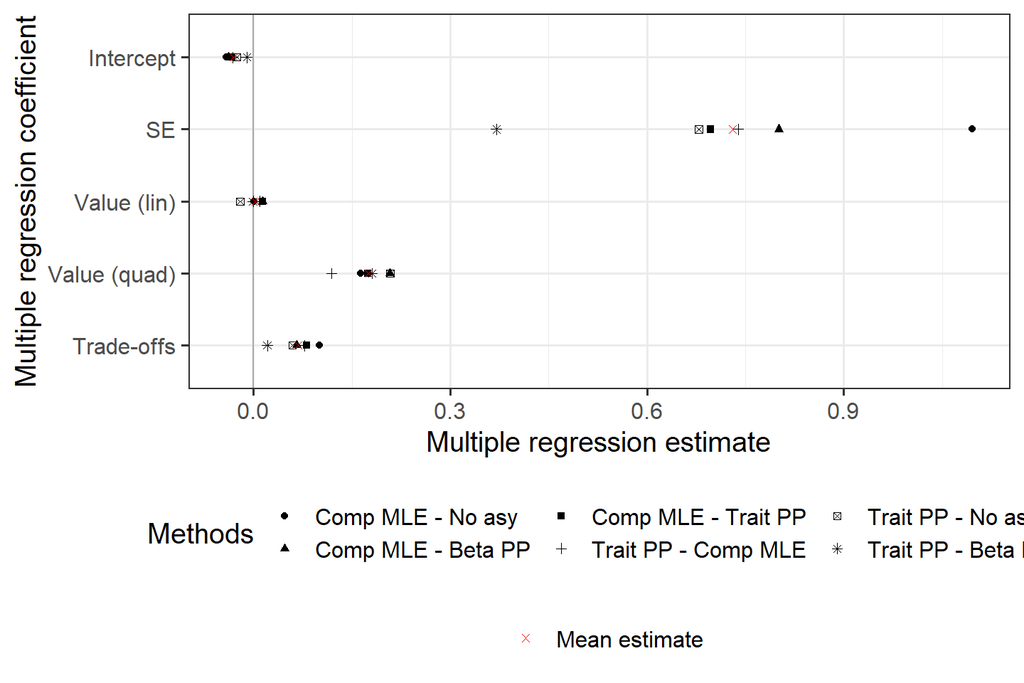

Overview of correlations in model with three best coefficients:

```
## # A tibble: 6 x 6
##   corr                    min    max median   mean     sd
##   <fct>                 <dbl>  <dbl>  <dbl>  <dbl>  <dbl>
## 1 y_c_quad - fungi_max -0.051 -0.041 -0.044 -0.045 0.0046
## 2 y_c - fungi_max      -0.19  -0.17  -0.18  -0.18  0.010
## 3 y_c - y_c_quad       -0.11  -0.060 -0.084 -0.085 0.025
## 4 se_c - fungi_max      0.14   0.33   0.24   0.24  0.062
## 5 se_c - y_c_quad      -0.23   0.082 -0.058 -0.070 0.14
## 6 se_c - y_c           -0.16  -0.058 -0.11  -0.11  0.040
```

# RAMP Model selection

RAMP results for selected method pairs:

```
## # A tibble: 6 x 9
##   cond_label   cond_iv_label r      r_c    data                   rmse rmsec main      inter
##   <fct>        <fct>         <list> <list> <list>                <dbl> <dbl> <list>    <list>
## 1 DV: Comp MLE IV: No asy    <RAMP> <RAMP> <tibble [1,676 x 52]> 0.052 0.051 <int [5]> <chr [12]>
## 2 DV: Comp MLE IV: Beta PP   <RAMP> <RAMP> <tibble [1,661 x 52]> 0.038 0.038 <int [8]> <chr [28]>
## 3 DV: Comp MLE IV: Trait PP  <RAMP> <RAMP> <tibble [1,676 x 52]> 0.043 0.043 <int [6]> <chr [9]>
## 4 DV: Trait PP IV: Comp MLE  <RAMP> <RAMP> <tibble [1,676 x 52]> 0.042 0.042 <int [7]> <chr [11]>
## 5 DV: Trait PP IV: No asy    <RAMP> <RAMP> <tibble [1,684 x 52]> 0.041 0.041 <int [9]> <chr [26]>
## 6 DV: Trait PP IV: Beta PP   <RAMP> <RAMP> <tibble [1,669 x 52]> 0.026 0.027 <int [7]> <chr [13]>
```

Number of coefficients in RAMP model:

```
## # A tibble: 6 x 10
##   cond_label   cond_iv_label r      r_c    data                   rmse rmsec main      inter          n
##   <fct>        <fct>         <list> <list> <list>                <dbl> <dbl> <list>    <list>     <dbl>
## 1 DV: Comp MLE IV: No asy    <RAMP> <RAMP> <tibble [1,676 x 52]> 0.052 0.051 <int [5]> <chr [12]>    18
## 2 DV: Comp MLE IV: Beta PP   <RAMP> <RAMP> <tibble [1,661 x 52]> 0.038 0.038 <int [8]> <chr [28]>    37
## 3 DV: Comp MLE IV: Trait PP  <RAMP> <RAMP> <tibble [1,676 x 52]> 0.043 0.043 <int [6]> <chr [9]>     16
## 4 DV: Trait PP IV: Comp MLE  <RAMP> <RAMP> <tibble [1,676 x 52]> 0.042 0.042 <int [7]> <chr [11]>    19
## 5 DV: Trait PP IV: No asy    <RAMP> <RAMP> <tibble [1,684 x 52]> 0.041 0.041 <int [9]> <chr [26]>    36
## 6 DV: Trait PP IV: Beta PP   <RAMP> <RAMP> <tibble [1,669 x 52]> 0.026 0.027 <int [7]> <chr [13]>    21
```

Inclusion probability of interactions (only selected method pairs):

```
##                 se_c fungi_max log.rel_weight. log.rel_n_w. y_c sd_emp_inv rho_med log1p.p_hetero. log1p.p_fit_x.
## se_c               4         4               2            3   1          3       5               1              4
## fungi_max          0         5               3            3   2          1       4               1              4
## log.rel_weight.    0         0               4            4   1          0       4               0              2
## log.rel_n_w.       0         0               0            2   2          5       2               2              2
## y_c                0         0               0            0   3          1       1               2              2
## sd_emp_inv         0         0               0            0   0          3       0               1              3
## rho_med            0         0               0            0   0          0       1               0              1
## log1p.p_hetero.    0         0               0            0   0          0       0               0              0
## log1p.p_fit_x.     0         0               0            0   0          0       0               0              1
```

```
## [1] 0
```

```
## [1] 3
```

```
## [1] 8
```

```
## [1] 7
```

```
## [1] 10
```

```
## [1] 11
```

```
## [1] 6
```

```
## [1] 45
```

RAMP results for all method pairs:

```
## # A tibble: 14 x 9
##    cond_label   cond_iv_label  r      r_c    data                   rmse rmsec main      inter
##    <fct>        <fct>          <list> <list> <list>                <dbl> <dbl> <list>    <list>
##  1 DV: Comp MLE IV: Comp Bayes <RAMP> <RAMP> <tibble [1,676 x 52]> 0.059 0.060 <int [6]> <chr [9]>
##  2 DV: Comp MLE IV: No asy     <RAMP> <RAMP> <tibble [1,676 x 52]> 0.052 0.051 <int [5]> <chr [12]>
##  3 DV: Comp MLE IV: No PB      <RAMP> <RAMP> <tibble [1,639 x 52]> 0.061 0.061 <int [7]> <chr [14]>
##  4 DV: Comp MLE IV: No NPB     <RAMP> <RAMP> <tibble [1,630 x 52]> 0.055 0.055 <int [6]> <chr [9]>
##  5 DV: Comp MLE IV: Beta PP    <RAMP> <RAMP> <tibble [1,661 x 52]> 0.038 0.038 <int [8]> <chr [28]>
##  6 DV: Comp MLE IV: Trait_u PP <RAMP> <RAMP> <tibble [1,487 x 52]> 0.038 0.038 <int [7]> <chr [11]>
##  7 DV: Comp MLE IV: Trait PP   <RAMP> <RAMP> <tibble [1,676 x 52]> 0.043 0.043 <int [6]> <chr [9]>
##  8 DV: Trait PP IV: Comp MLE   <RAMP> <RAMP> <tibble [1,676 x 52]> 0.042 0.042 <int [7]> <chr [11]>
##  9 DV: Trait PP IV: Comp Bayes <RAMP> <RAMP> <tibble [1,684 x 52]> 0.064 0.063 <int [9]> <chr [25]>
## 10 DV: Trait PP IV: No asy     <RAMP> <RAMP> <tibble [1,684 x 52]> 0.041 0.041 <int [9]> <chr [26]>
## 11 DV: Trait PP IV: No PB      <RAMP> <RAMP> <tibble [1,647 x 52]> 0.058 0.058 <int [7]> <chr [6]>
## 12 DV: Trait PP IV: No NPB     <RAMP> <RAMP> <tibble [1,635 x 52]> 0.049 0.049 <int [6]> <chr [4]>
## 13 DV: Trait PP IV: Beta PP    <RAMP> <RAMP> <tibble [1,669 x 52]> 0.026 0.027 <int [7]> <chr [13]>
## 14 DV: Trait PP IV: Trait_u PP <RAMP> <RAMP> <tibble [1,491 x 52]> 0.022 0.021 <int [7]> <chr [16]>
```

Inclusion of interaction for all method pairs:

```
##                 se_c fungi_max log.rel_weight. log.rel_n_w.  y_c sd_emp_inv rho_med log1p.p_hetero. log1p.p_fit_x.
## se_c            0.71      0.79            0.29         0.64 0.29       0.36    0.57            0.07           0.64
## fungi_max       0.00      0.64            0.29         0.36 0.36       0.07    0.43            0.07           0.29
## log.rel_weight. 0.00      0.00            0.43         0.43 0.14       0.00    0.43            0.00           0.36
## log.rel_n_w.    0.00      0.00            0.00         0.36 0.50       0.50    0.21            0.14           0.43
## y_c             0.00      0.00            0.00         0.00 0.71       0.21    0.21            0.21           0.36
## sd_emp_inv      0.00      0.00            0.00         0.00 0.00       0.29    0.00            0.07           0.36
## rho_med         0.00      0.00            0.00         0.00 0.00       0.00    0.14            0.00           0.07
## log1p.p_hetero. 0.00      0.00            0.00         0.00 0.00       0.00    0.00            0.00           0.07
## log1p.p_fit_x.  0.00      0.00            0.00         0.00 0.00       0.00    0.00            0.00           0.29
```